# Sports Analytics Final Project

Jacob Cathcart, David Grubb, Reid Motter

12/11/2018

# Introduction

The topic we chose for our final project was conference realignment of the Power 5 college football teams. Our aim is to develop 4 new super-conferences that are optimized for distance between teams and also preserves rivalries. The reason for choosing this topic is two fold, first we all have a general interest and knowledge of college football, which we think will aid us in determining the best super-conference structure. Secondly, as tensions rise between the NCAA and the largest teams in college football we believe conference reordering is a eventuality in college football. As it currently stands, the NCAA’s Division I sports teams are broken up into the Power 5 conferences(ACC, Big Ten, Big 12, PAC-12, SEC) aside from a few independent schools. The following is each school mapped and colored based on its conference affiliation.

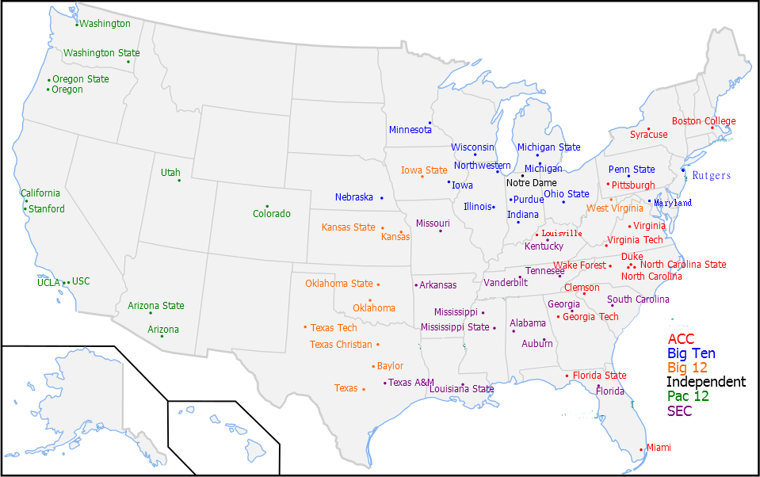

Notre Dame is shown as one of the independent schools so we decided to included it as well as BYU, another large NCAA Division I school, in our re-conferencing. The conferences have been subject to many shifts and realignments over the years, but moving away from the NCAA would be a major first in any college sport. After a short time discussing the problem, we recognized that the k-means clustering, using the latitudes and longitudes of each school, would be ideal in creating distance optimized conferences.

# Methodology

To start our project we needed to first find the right data. We achieved this by selecting a dataset of US cities from simplemaps.com. This dataset includes every city in the United States and is primarily a population dataset including variables such as population and density, but the important part for us was the latitude and longitude of each city. We filtered the data in excel by eliminating all columns except city, state name, latitude and longitude. This clean data was then read into R in csv format. We grouped the data by city, state, and lat/long coordinates. We filtered our clean data from the csv, by selecting the city and state that each team from the Power Five conferences reside in, including Notre Dame and BYU. We rewrote the csv and exported back to excel to add the team names to corresponding coordinates. The new excel file was then imported back into R to start manipulating the data. After cleaning the data we used K-means cluster analysis in order to cluster the teams based on their locations relative to each other. The K-means analysis gave us four clusters, one for each conference, but since it only optimizes for distance our next step was to look at the 4 conferences and move some teams around in order to preserve existing rivalries. Once we had the conferences that both optimized for distance and maintained rivalries we simply split each conference into two divisions based on location within the conference and created a schedule for each conference.

Using K-means clustering we clustered the teams based on their latitude and longitude. This gave us 4 conferences with minimized distance to eachother.

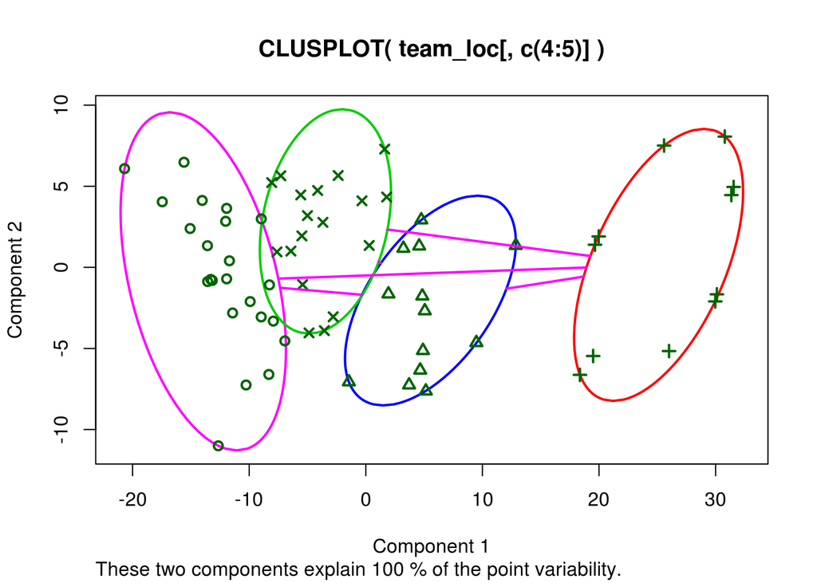

Using our clusters as our conferences, we plotted each team on a map of the United States.

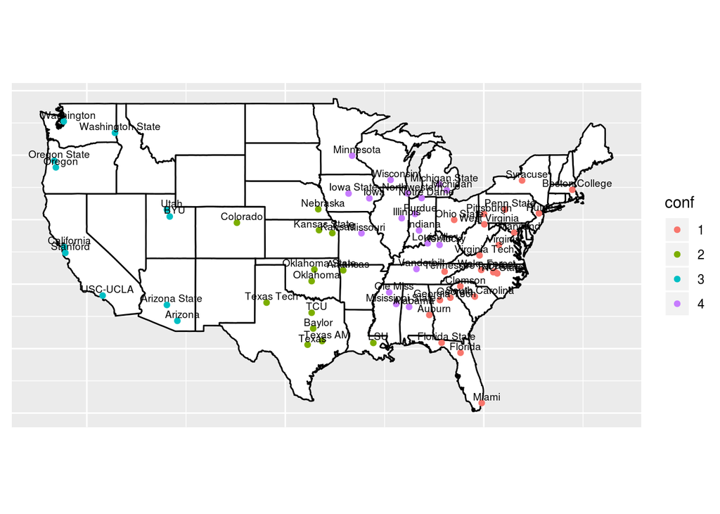

Here we built a simple counter to tell us how many teams we had in each conference.

```
## [1] 23 13 11 18
```

### Now our conferences look like this.

```
## [1] 17 17 16 15
```

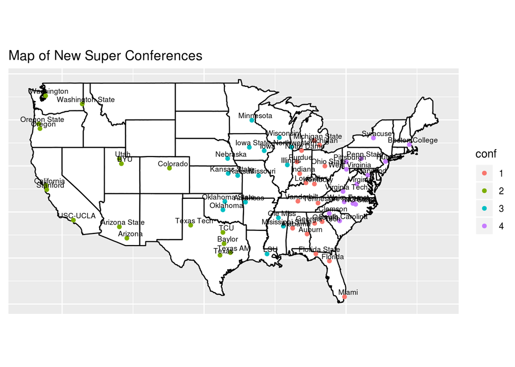

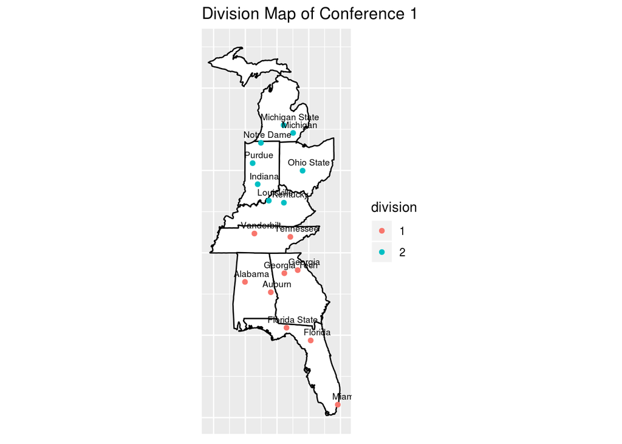

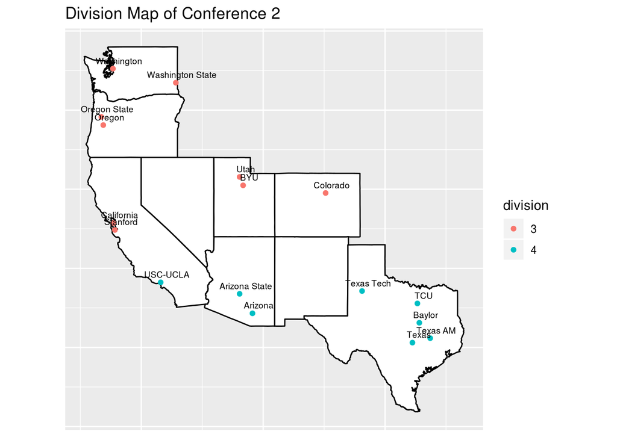

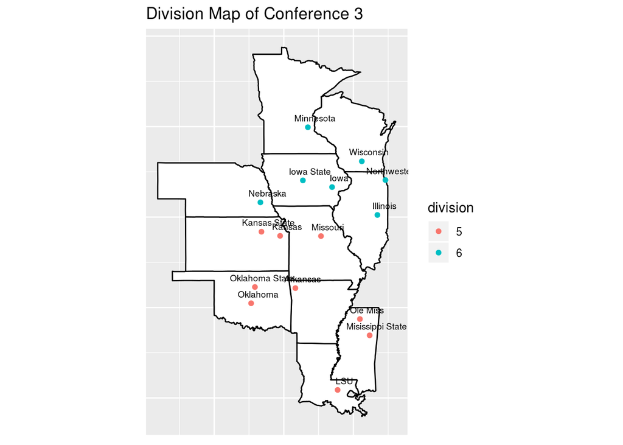

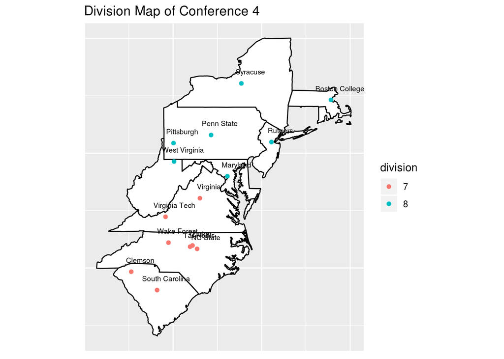

Conf 1

North: Michigan State, Michigan, Notre Dame, Purdue, Indiana, Louisville, Kentucky, Ohio State

South: Vanderbilt, Tennessee, Georgia, Georgia Tech, Alabama, Auburn, Florida State, Florida, Miami

Conf 2

North: Washington, Washington State, Oregon State, Oregon, Utah, BYU, Colorado, California, Stanford

South: USC, UCLA, Arizona State, Arizona, Texas Tech, TCU, Baylor Texas, Texas A&M

Conf 3

North: Minnesota, Wisconsin, Iowa State, Iowa, Northwestern, Illinois, Nebraska

South: Kansas State, Kansas, Missouri, Oklahoma State, Arkansas, Oklahoma, Ole Miss, Mississippi State, LSU

Conf 4

North: Syracuse, Boston College, Penn State, Pittsburgh, Rutgers, West Virginia, Maryland

South: Virginia, Virginia Tech, Wake, NC State, Duke, UNC, Clemson, South Carolina

# Scheduling

Non-divisional Conference games would vary from year to year. These non-divisional games would also set up big time match-ups between football blue-bloods. An example of this could be Penn State vs Clemson in conference 4, Wisconsin vs LSU in conference 3, Stanford vs Texas in conference 2, and Ohio State vs Alabama in conference 1. There would be four total conference champions, and these would be decided by a championship game in each conference. The teams playing in the conference championship game would be based on their record in division, as well as, strength of schedule. These four teams would then enter into a four team playoff, closely following the current playoff structure, to determine a National Champion.